# Calcolo delle costanti caratteristiche in R

Isadora

# Per variabili discrete

## La media

Si consideri l’esperimento: lancio di due dadi, e le variabili casuali X=Risultato del primo lancio e Y=Somma dei due lanci.

Il supporto di X è:

```r
x <- 1:6
```

E la sua funzione di probabilità:

```r
p_X <- rep(1/6,6)
p_X
```

```
## [1] 0.1666667 0.1666667 0.1666667 0.1666667 0.1666667 0.1666667
```

Quindi, per calcolare Il valore atteso, possiamo fare:

```r
E_X <- sum(x*p_X)
```

- Qual è la media di Y?

```r
y <- 2:12 # somma di due dadi
p_Y <- c(1, 2, 3, 4, 5, 6, 5, 4, 3, 2, 1)/36
```

```r
E_Y <- sum(y*p_Y)
```

## La varianza

Possiamo calcolare la varianza usando la definizione:

```r
Var_X <- sum((x-E_X)^2*p_X)
Var_X
```

```
## [1] 2.916667
```

Oppure la formula ridotta:

```r
sum(x^2*p_X)-E_X^2
```

```
## [1] 2.916667
```

Chiaramente si ottiene lo stesso risultato.

- Qual è la varianza di Y?

```r
Var_Y <- sum((y-E_Y)^2*p_Y)
Var_Y
```

```
## [1] 5.833333
```

- Scarto quadratico medio viene fatto facendo la radice a Var

```r
Sq_X <- sqrt(Var_X)
Sq_Y <- sqrt(Var_Y)
Sq_X
```

```
## [1] 1.707825
```

```r
Sq_Y
```

```
## [1] 2.415229
```

- Per confrontare la dispersione di due variabili casuali, si usa il **coefficiente di variazione**

```r
CV_X <- sqrt(Var_X)/abs(E_X)
CV_Y <- sqrt(Var_Y)/abs(E_Y)
CV_X
```

```
## [1] 0.48795
```

```r
CV_Y
```

```
## [1] 0.3450328
```

## La mediana

Per calcolare la mediana, prima dobbiamo trovare la funzione di ripartizione:

```r
F_X <- cumsum(p_X)
F_X
```

```
## [1] 0.1666667 0.3333333 0.5000000 0.6666667 0.8333333 1.0000000
```

E poi trovare il primo valore nel supporto di X per il quale la probabilità accumulata raggiunge la soglia di 0.5:

```r
#library(mosaic)
```

```r
med_X <- x[which(F_X >= 0.5)[1]]
med_X
```

```
## [1] 3
```

E adesso una rappresentazione grafica:

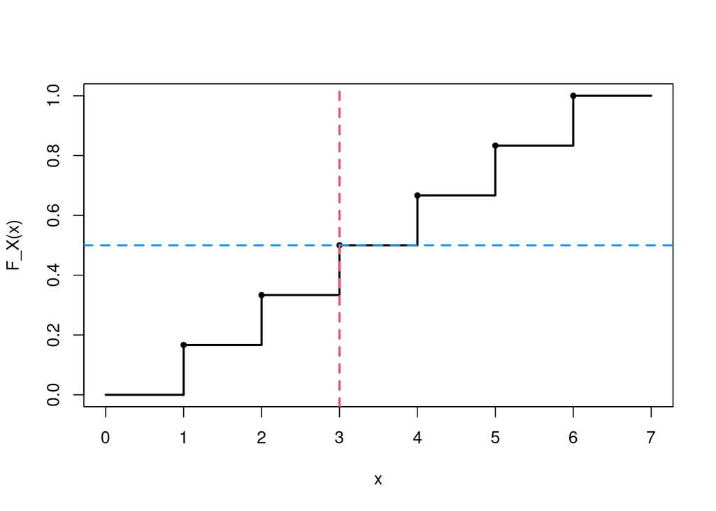

```r
plot(c(0,x,7), c(0,F_X,1), type="s", ylab="F_X(x)", xlab="x",lwd=2)
points(x, F_X, pch=20)
abline(v=med_X, col=2, lwd =2, lty=2)
abline(h=0.5, col=4, lwd=2, lty=2)
```

Osserviamo che, in realtà, la mediana potrebbe essere qualsiasi valore nell’intervallo $[3,4)$. In questi casi, per convenzione si usa il valore centrale:
$$med(X)=\frac{3+4}{2}=3.5$$
in questo modo, la mediana coincide con la media, come avevamo stabilito per qualsiasi distribuzione simmetrica.